# CCLE Analysis Project

Yu Jia

September 30, 2022

## Import data

I first downloaded the CCLE_mutations and expression data from the Broad DepMap portal (DepMap Public 22Q2 Primary Files, [Link](https://depmap.org/portal/download/)). I loaded the two datasets using the read_csv function.

## Take a `glimpse` into the data in the dataframe

Next, I found the CCLE_mutations table has 32 variables and 1,235,466 observations

```r
glimpse(mutations)
```

[output not shown]

## Clean the datasets

I began to select variables as **Hugo_Symbol**, **Variant_Classification**, **DepMap_ID** and **isDeleterious**. Next I tried to filter out the cell lines that have mutations in *RNF43*.

| Hugo_Symbol | Variant_Classification | DepMap_ID | isDeleterious |
| --- | --- | --- | --- |
| RNF43 | Missense_Mutation | ACH-000022 | FALSE |
| RNF43 | Missense_Mutation | ACH-000023 | FALSE |
| RNF43 | Frame_Shift_Ins | ACH-000060 | TRUE |
| RNF43 | Nonsense_Mutation | ACH-000094 | TRUE |
| RNF43 | Frame_Shift_Del | ACH-000107 | TRUE |
| RNF43 | Frame_Shift_Del | ACH-000136 | TRUE |
| RNF43 | Nonsense_Mutation | ACH-000222 | TRUE |
| RNF43 | Missense_Mutation | ACH-000313 | FALSE |
| RNF43 | Silent | ACH-000352 | FALSE |
| RNF43 | De_novo_Start_OutOfFrame | ACH-000375 | TRUE |

[output cut: 124 more lines]

I found out that there are two tpyes of frameshift mutations, either deletion or insertion. I combined these two types of frameshift mutations.

| Hugo_Symbol | Variant_Classification | DepMap_ID | isDeleterious |
| --- | --- | --- | --- |
| RNF43 | Missense_Mutation | ACH-000022 | FALSE |
| RNF43 | Missense_Mutation | ACH-000023 | FALSE |
| RNF43 | Frame_Shift | ACH-000060 | TRUE |
| RNF43 | Nonsense_Mutation | ACH-000094 | TRUE |
| RNF43 | Frame_Shift | ACH-000107 | TRUE |
| RNF43 | Frame_Shift | ACH-000136 | TRUE |
| RNF43 | Nonsense_Mutation | ACH-000222 | TRUE |
| RNF43 | Missense_Mutation | ACH-000313 | FALSE |
| RNF43 | Silent | ACH-000352 | FALSE |
| RNF43 | De_novo_Start_OutOfFrame | ACH-000375 | TRUE |

[output cut: 124 more lines]

Next, I opened the expression dataset and filtered out the expression for gene of interest *Axin2*.

| DepMap_ID | AXIN2 |
| --- | --- |
| ACH-001113 | 0.95605665 |
| ACH-001289 | 1.58014548 |
| ACH-001339 | 1.09761080 |
| ACH-001538 | 0.00000000 |
| ACH-000242 | 0.27500705 |
| ACH-000708 | 5.79467579 |
| ACH-000327 | 0.53605290 |
| ACH-000233 | 1.09761080 |
| ACH-000461 | 5.80632406 |
| ACH-000705 | 1.16349873 |

[output cut: 1396 more lines]

I joined the two dataset together using the inner_join function.

| Hugo_Symbol | Variant_Classification | DepMap_ID | isDeleterious | AXIN2 |
| --- | --- | --- | --- | --- |
| RNF43 | Missense_Mutation | ACH-000022 | FALSE | 4.21179098 |
| RNF43 | Missense_Mutation | ACH-000023 | FALSE | 0.83187724 |
| RNF43 | Frame_Shift | ACH-000060 | TRUE | 0.12432814 |
| RNF43 | Nonsense_Mutation | ACH-000094 | TRUE | 2.63691458 |
| RNF43 | Frame_Shift | ACH-000107 | TRUE | 1.91838623 |
| RNF43 | Frame_Shift | ACH-000136 | TRUE | 2.35895883 |
| RNF43 | Nonsense_Mutation | ACH-000222 | TRUE | 1.83592407 |
| RNF43 | Missense_Mutation | ACH-000313 | FALSE | 0.17632277 |
| RNF43 | Silent | ACH-000352 | FALSE | 0.13750352 |
| RNF43 | De_novo_Start_OutOfFrame | ACH-000375 | TRUE | 0.25096157 |

[output cut: 107 more lines]

## EDA Graph

I would like to see whether the type of *RNF43* mutations will change the *AXIN2* expression. I decided to use the boxplot for the graph.

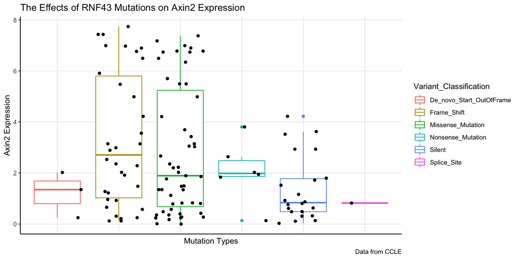

## Conclusions

Compared to silent mutations, other types of mutations including frameshift and missense mutations appear to increase the Wnt target gene Axin2 expression in cancer cell lines.

## Prioritized follow-up studies

Some cell lines with missense mutations have very high Axin2 levels. It is interesting to see where these mutations are in the protein and whether they are located in a functional domain.

## Acknolwedgements

I would like to acknowledge Prof. Matthew Herschey for the help in learning.